# Taller Global — Modelos Lineales Generalizados

- Show All Code
- Hide All Code
- View Source

Author

Jorge Andrés Sánchez Duarte

Published

May 20, 2026

# 1 Ejercicio 1 — Peso al nacer (Modelo Gaussiano)

**Contexto**

**Fuente:** Dobson y Barnett (2008, p. 23)

Los siguientes datos corresponden a los **pesos al nacer** (en gramos) y la **edad gestacional estimada** (en semanas) de 24 bebés, clasificados por sexo.

**Ver código**

```r
datos_bebes <- data.frame(
  Sexo = factor(c(rep("Mujer", 12), rep("Hombre", 12))),
  Edad = c(
    40, 36, 40, 38, 42, 39, 40, 37, 36, 38, 39, 40,
    40, 38, 40, 35, 36, 37, 41, 40, 37, 38, 40, 38
  ),
  Peso = c(
    3317, 2729, 2935, 2754, 3210, 2817, 3126, 2539,
    2412, 2991, 2875, 3231, 2968, 2795, 3163, 2925,
    2625, 2847, 3292, 3473, 2628, 3176, 3421, 2975
  )
)

datos_bebes |>
  kable(caption = "Datos de bebés: peso al nacer y edad gestacional") |>
  kable_styling(bootstrap_options = c("striped", "hover", "condensed"),
                full_width = FALSE)
```

Datos de bebés: peso al nacer y edad gestacional

| Sexo | Edad | Peso |
| --- | --- | --- |
| Mujer | 40 | 3317 |
| Mujer | 36 | 2729 |
| Mujer | 40 | 2935 |
| Mujer | 38 | 2754 |
| Mujer | 42 | 3210 |
| Mujer | 39 | 2817 |
| Mujer | 40 | 3126 |
| Mujer | 37 | 2539 |
| Mujer | 36 | 2412 |
| Mujer | 38 | 2991 |
| Mujer | 39 | 2875 |
| Mujer | 40 | 3231 |
| Hombre | 40 | 2968 |
| Hombre | 38 | 2795 |
| Hombre | 40 | 3163 |
| Hombre | 35 | 2925 |
| Hombre | 36 | 2625 |
| Hombre | 37 | 2847 |
| Hombre | 41 | 3292 |
| Hombre | 40 | 3473 |
| Hombre | 37 | 2628 |
| Hombre | 38 | 3176 |
| Hombre | 40 | 3421 |
| Hombre | 38 | 2975 |

## 1.1 a) Ajuste del modelo

Se ajusta un **GLM de respuesta normal** con función de enlace identidad, incluyendo edad gestacional, sexo y su interacción:

**Ver código**

```r
modelo1 <- glm(Peso ~ Edad * Sexo,
               data   = datos_bebes,
               family = gaussian(link = "identity"))
```

## 1.2 b) Efecto de la edad gestacional por sexo

## 1.3 Pregunta

¿Es el efecto de la edad gestacional sobre el peso al nacer el mismo para niños y niñas? (α = 5%)

**Ver código**

```r
summary(modelo1)
```

```
Call:
glm(formula = Peso ~ Edad * Sexo, family = gaussian(link = "identity"),
    data = datos_bebes)

Coefficients:
               Estimate Std. Error t value Pr(>|t|)
(Intercept)    -1268.67    1114.64  -1.138 0.268492
Edad             111.98      29.05   3.855 0.000986 ***
SexoMujer       -872.99    1611.33  -0.542 0.593952
Edad:SexoMujer    18.42      41.76   0.441 0.663893
---
Signif. codes:  0 '***' 0.001 '**' 0.01 '*' 0.05 '.' 0.1 ' ' 1

(Dispersion parameter for gaussian family taken to be 32621.23)

    Null deviance: 1829873  on 23  degrees of freedom
Residual deviance:  652425  on 20  degrees of freedom
AIC: 323.16

Number of Fisher Scoring iterations: 2
```

**Conclusión**

El p-valor de la interacción `Edad:SexoMujer` es **0.664 > 0.05**, por lo tanto **no rechazamos H₀**. El efecto de la edad gestacional sobre el peso al nacer **es el mismo para niños y niñas**.

## 1.4 c) Diagnóstico del modelo

**Diagnóstico general**

**Ver código**

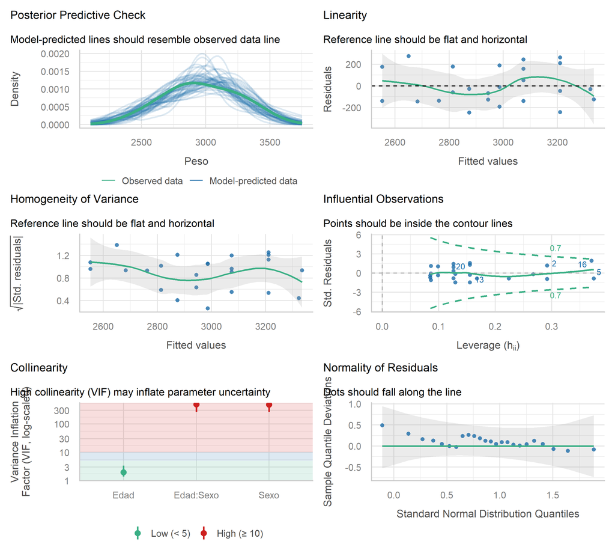

```r
check_model(modelo1)
```

Los residuos no son normales y existen serios problemas de multicolinealidad. Se observa un posible valor influyente y hay indicios de heterodasticidad.

**Envelope y Cook’s Distance**

**Ver código**

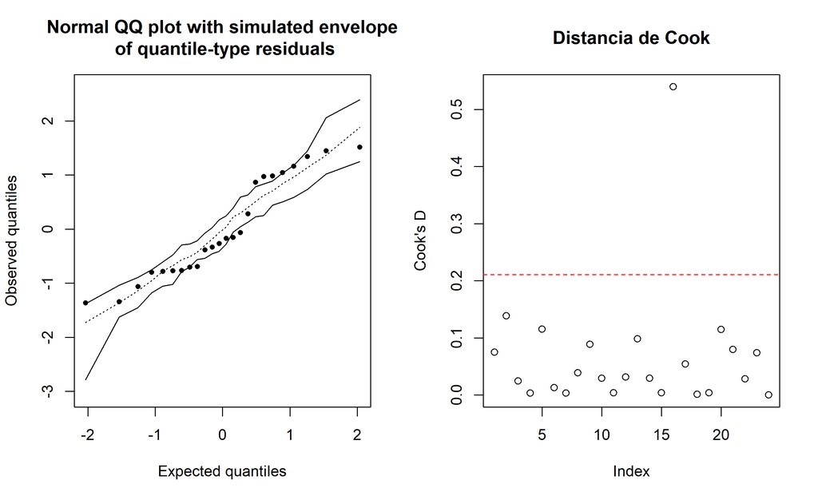

```r
old <- sink(tempfile())
par(mfrow = c(1, 2))
envelope(modelo1)
plot(cooks.distance(modelo1), main = "Distancia de Cook", ylab = "Cook's D")
abline(h = 4 / (nrow(datos_bebes) - length(coef(modelo1)) - 1),
       col = "red", lty = 2)
```

**Ver código**

```r
sink(old)
```

**Warning**

## 1.5 d) Interpretación de parámetros

Solo interpretamos los coeficientes estadísticamente significativos:

> **Edad:** Un aumento de una semana en la edad gestacional se asocia con un incremento esperado de **111.98 gramos** en el peso al nacer, manteniendo constante el efecto del sexo.

## 1.6 e) Predicción — Bebé de sexo femenino, 40 semanas

**Ver código**

```r
nuevo_dato <- data.frame(Edad = 40, Sexo = factor("Mujer"))
pred1 <- predict(modelo1, newdata = nuevo_dato, type = "response")
cat("Peso esperado:", round(pred1, 2), "gramos\n")
```

```
Peso esperado: 3074.33 gramos
```

**Resultado**

Se estima que una bebé de sexo femenino con **40 semanas de gestación** tendrá un peso promedio de **3074.33 gramos**.

# 2 Ejercicio 2 — Senilidad y escala de Wechsler (Modelo Binomial)

**Contexto**

**Fuente:** Dobson y Barnett (2008, p. 140)

Una muestra de personas de edad avanzada fue sometida a un examen psiquiátrico para detectar síntomas de senilidad. Se registró el puntaje en la **escala de inteligencia de Wechsler** y la presencia (1) o ausencia (0) de síntomas.

**Ver código**

```r
head(datos_senilidad) |>
  kable(caption = "Primeras filas: escala de Wechsler y senilidad") |>
  kable_styling(bootstrap_options = c("striped", "hover"), full_width = FALSE)
```

Primeras filas: escala de Wechsler y senilidad

| Escala | Senilidad |
| --- | --- |
| 9 | 1 |
| 13 | 1 |
| 6 | 1 |
| 8 | 1 |
| 10 | 1 |
| 4 | 1 |

## 2.1 a) Selección de función de enlace

Se ajustan tres modelos con distintas funciones de enlace:

**Ver código**

```r
modelo2.1 <- glm(Senilidad ~ Escala, data = datos_senilidad,
                 family = binomial(link = "logit"))
modelo2.2 <- glm(Senilidad ~ Escala, data = datos_senilidad,
                 family = binomial(link = "probit"))
modelo2.3 <- glm(Senilidad ~ Escala, data = datos_senilidad,
                 family = binomial(link = "cloglog"))

data.frame(
  Enlace = c("Logit", "Probit", "Cloglog"),
  AIC    = round(c(AIC(modelo2.1), AIC(modelo2.2), AIC(modelo2.3)), 4),
  BIC    = round(c(BIC(modelo2.1), BIC(modelo2.2), BIC(modelo2.3)), 4)
) |>
  kable(caption = "Comparación de modelos por AIC y BIC") |>
  kable_styling(bootstrap_options = c("striped", "hover"), full_width = FALSE) |>
  row_spec(1, bold = TRUE, color = "white", background = "#2c7bb6")
```

Comparación de modelos por AIC y BIC

| Enlace | AIC | BIC |
| --- | --- | --- |
| Logit | 55.0174 | 58.9953 |
| Probit | 54.9836 | 58.9615 |
| Cloglog | 55.3107 | 59.2887 |

**Modelo seleccionado: Logit**

Aunque el probit obtiene el menor AIC/BIC, la diferencia es marginal. Se elige el **enlace logit** por su **mayor interpretabilidad** (odds ratios).

## 2.2 b) Pruebas de hipótesis

**Prueba de Wald**

**Ver código**

```r
summary(modelo2.1)
```

```
Call:
glm(formula = Senilidad ~ Escala, family = binomial(link = "logit"),
    data = datos_senilidad)

Coefficients:
            Estimate Std. Error z value Pr(>|z|)
(Intercept)   2.4040     1.1918   2.017  0.04369 *
Escala       -0.3235     0.1140  -2.838  0.00453 **
---
Signif. codes:  0 '***' 0.001 '**' 0.01 '*' 0.05 '.' 0.1 ' ' 1

(Dispersion parameter for binomial family taken to be 1)

    Null deviance: 61.806  on 53  degrees of freedom
Residual deviance: 51.017  on 52  degrees of freedom
AIC: 55.017

Number of Fisher Scoring iterations: 5
```

El p-valor de la escala de Wechsler es **0.00453 < 0.05** → se rechaza H₀. El puntaje de Wechsler **sí afecta** la probabilidad de tener senilidad.

**Razón de Verosimilitudes**

**Ver código**

```r
modelo2.0 <- glm(Senilidad ~ 1, data = datos_senilidad,
                 family = binomial(link = "probit"))
lrtest(modelo2.0, modelo2.1)
```

| #Df | LogLik | Df | Chisq | Pr(>Chisq) |
| --- | --- | --- | --- | --- |
| 1 | -30.90316 | NA | NA | NA |
| 2 | -25.50869 | 1 | 10.78894 | 0.0010211 |

Con p-valor < 0.05, la inclusión del puntaje de Wechsler **mejora significativamente** el ajuste del modelo.

## 2.3 c) Diagnóstico del modelo

**Diagnóstico general**

**Ver código**

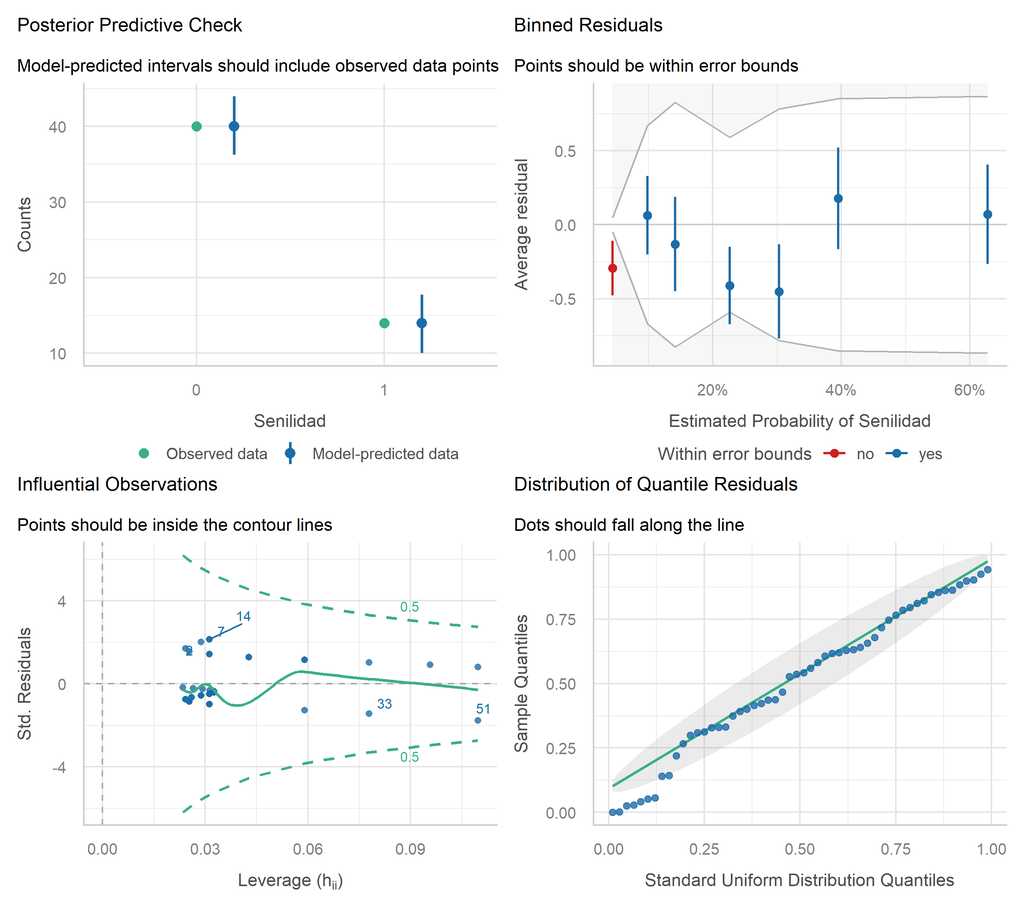

```r
check_model(modelo2.1)
```

Residuos uniformes. La distribución de datos observados se aproxima bien a los simulados. No hay evidencia clara de violación de linealidad.

**Envelope y Cook’s Distance**

**Ver código**

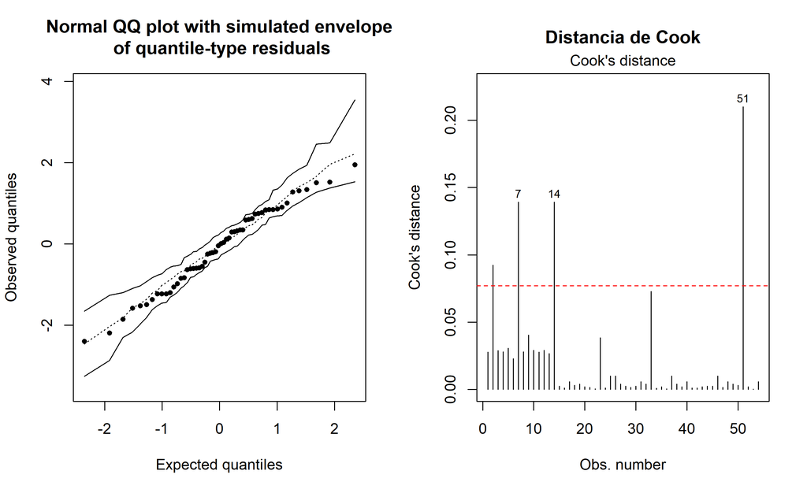

```r
old <- sink(tempfile())
par(mfrow = c(1, 2))
envelope(modelo2.1)
plot(modelo2.1, which = 4, main = "Distancia de Cook")
abline(h = 4 / (nrow(datos_senilidad) - 2), col = "red", lty = 2)
```

**Ver código**

```r
sink(old)
```

**Warning**

## 2.4 d) Interpretación de parámetros

> **exp(−0.3235) = 0.7235** → Por cada punto adicional en la escala de Wechsler, el *odds* de tener senilidad disminuye aproximadamente un **27.65%**.

## 2.5 e) Predicción — 15 puntos en la escala de Wechsler

**Ver código**

```r
pred2 <- predict(modelo2.1, newdata = data.frame(Escala = 15), type = "response")
cat("Probabilidad estimada:", round(pred2, 6), "\n")
```

```
Probabilidad estimada: 0.079518
```

**Resultado**

La probabilidad estimada de presentar síntomas de senilidad con **15 puntos** en la escala de Wechsler es **0.0795** (~7.95%).

# 3 Ejercicio 3 — Mortalidad de insectos (Rotenona)

**Contexto**

**Fuente:** Olsson (2002, p. 33)

Experimento donde lotes de ~50 insectos fueron expuestos a distintas concentraciones del plaguicida **rotenona**. Se registró el número de insectos muertos.

**Ver código**

```r
datos_insectos |>
  mutate(Tasa = round(Muertos / Expuestos, 3)) |>
  kable(caption = "Datos de mortalidad por concentración de rotenona") |>
  kable_styling(bootstrap_options = c("striped", "hover"), full_width = FALSE)
```

Datos de mortalidad por concentración de rotenona

| Dosis | Expuestos | Muertos | Tasa |
| --- | --- | --- | --- |
| 0.41 | 50 | 6 | 0.120 |
| 0.58 | 48 | 16 | 0.333 |
| 0.71 | 46 | 24 | 0.522 |
| 0.89 | 49 | 42 | 0.857 |
| 1.01 | 50 | 44 | 0.880 |

## 3.1 a) Gráfico de tasa de mortalidad

**Ver código**

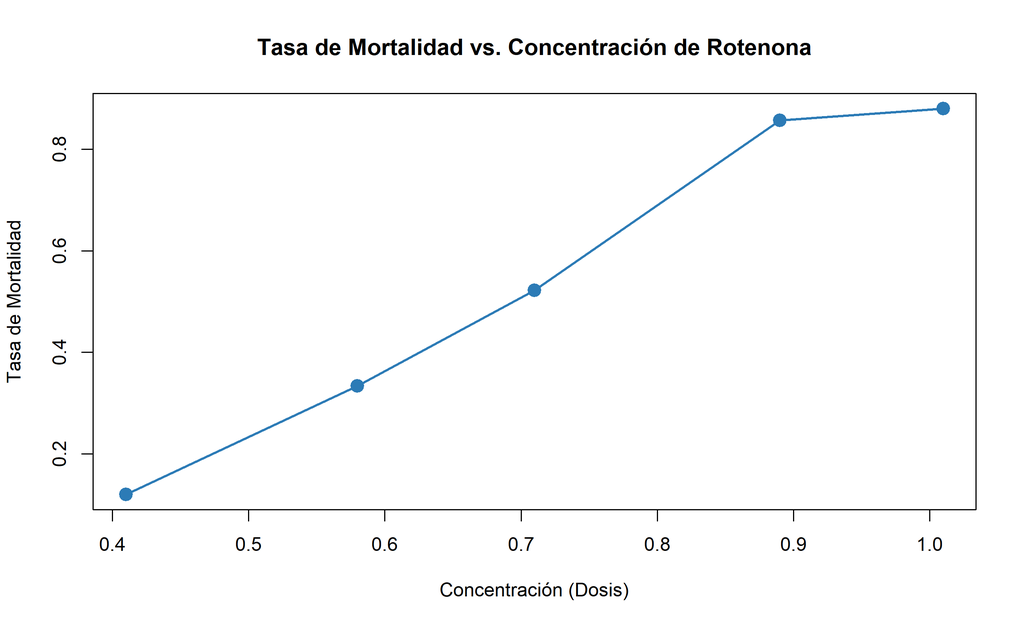

```r
tasa <- datos_insectos$Muertos / datos_insectos$Expuestos

plot(y = tasa, x = datos_insectos$Dosis,
     main = "Tasa de Mortalidad vs. Concentración de Rotenona",
     xlab = "Concentración (Dosis)", ylab = "Tasa de Mortalidad",
     pch = 19, col = "#2c7bb6", cex = 1.5)
lines(y = tasa, x = datos_insectos$Dosis, col = "#2c7bb6", lwd = 2)
```

Se observa una **relación directa** entre la dosis y la tasa de mortalidad: a mayor concentración, mayor proporción de insectos muertos.

## 3.2 b) Comparación gráfica de modelos

**Ver código**

```r
modelo3.1 <- glm(cbind(Muertos, Expuestos - Muertos) ~ Dosis,
                 data = datos_insectos, family = binomial(link = "logit"))
modelo3.2 <- glm(cbind(Muertos, Expuestos - Muertos) ~ Dosis,
                 data = datos_insectos, family = binomial(link = "probit"))
modelo3.3 <- glm(cbind(Muertos, Expuestos - Muertos) ~ Dosis,
                 data = datos_insectos, family = binomial(link = "cloglog"))
```

**Ver código**

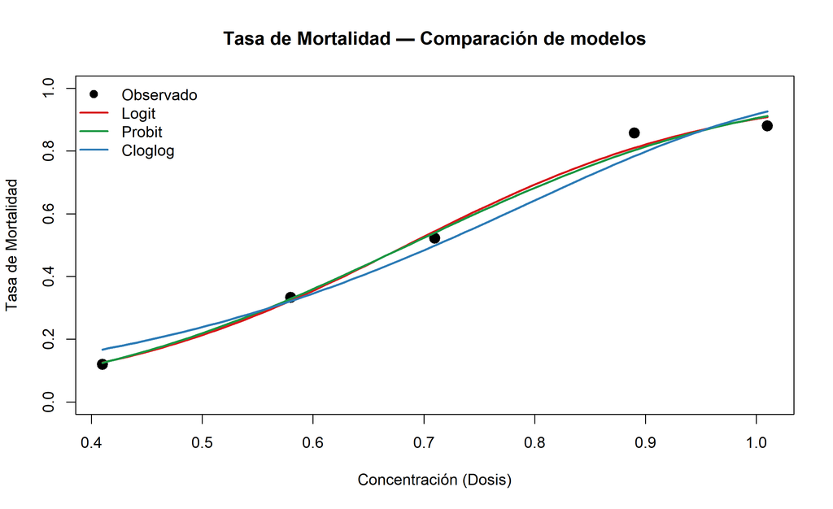

```r
plot(y = tasa, x = datos_insectos$Dosis,
     main = "Tasa de Mortalidad — Comparación de modelos",
     xlab = "Concentración (Dosis)", ylab = "Tasa de Mortalidad",
     pch = 19, col = "black", cex = 1.5, ylim = c(0, 1))
lines(dosis_pred, pred_logit,   col = "#d7191c", lwd = 2.5)
lines(dosis_pred, pred_probit,  col = "#1a9641", lwd = 2.5)
lines(dosis_pred, pred_cloglog, col = "#2c7bb6", lwd = 2.5)
legend("topleft",
       legend = c("Observado", "Logit", "Probit", "Cloglog"),
       col    = c("black", "#d7191c", "#1a9641", "#2c7bb6"),
       lty    = c(NA, 1, 1, 1),
       pch    = c(19, NA, NA, NA),
       lwd    = 2, bty = "n")
```

Los modelos **logit** y **probit** ajustan mejor los datos observados.

## 3.3 c) Selección del mejor modelo

**Ver código**

```r
data.frame(
  Enlace   = c("Logit", "Probit", "Cloglog"),
  AIC      = round(c(AIC(modelo3.1),      AIC(modelo3.2),      AIC(modelo3.3)),      4),
  Desviance = round(c(deviance(modelo3.1), deviance(modelo3.2), deviance(modelo3.3)), 4)
) |>
  kable(caption = "Comparación de modelos — AIC y Desvío") |>
  kable_styling(bootstrap_options = c("striped", "hover"), full_width = FALSE) |>
  row_spec(1, bold = TRUE, color = "white", background = "#2c7bb6")
```

Comparación de modelos — AIC y Desvío

| Enlace | AIC | Desviance |
| --- | --- | --- |
| Logit | 24.5685 | 1.3481 |
| Probit | 24.8590 | 1.6386 |
| Cloglog | 27.2559 | 4.0355 |

**Modelo seleccionado: Logit**

Obtuvo el **menor AIC y desvío**. Además produce predicciones coherentes con los datos observados.

## 3.4 d) Pruebas de hipótesis

**Prueba de Wald**

**Ver código**

```r
summary(modelo3.1)
```

```
Call:
glm(formula = cbind(Muertos, Expuestos - Muertos) ~ Dosis, family = binomial(link = "logit"),
    data = datos_insectos)

Coefficients:
            Estimate Std. Error z value Pr(>|z|)
(Intercept)  -4.8387     0.6377  -7.588 3.24e-14 ***
Dosis         7.0681     0.8826   8.009 1.16e-15 ***
---
Signif. codes:  0 '***' 0.001 '**' 0.01 '*' 0.05 '.' 0.1 ' ' 1

(Dispersion parameter for binomial family taken to be 1)

    Null deviance: 96.6881  on 4  degrees of freedom
Residual deviance:  1.3481  on 3  degrees of freedom
AIC: 24.568

Number of Fisher Scoring iterations: 4
```

P-valor = **1.16e-15 < 0.05** → La concentración del plaguicida **sí afecta** la probabilidad de muerte.

**Razón de Verosimilitudes**

**Ver código**

```r
modelo3.0 <- glm(cbind(Muertos, Expuestos - Muertos) ~ 1,
                 data = datos_insectos, family = binomial(link = "logit"))
lrtest(modelo3.0, modelo3.1)
```

| #Df | LogLik | Df | Chisq | Pr(>Chisq) |
| --- | --- | --- | --- | --- |
| 1 | -57.95427 | NA | NA | NA |
| 2 | -10.28423 | 1 | 95.34008 | 0 |

P-valor = **2.2e-16 < 0.05** → La dosis es un predictor **esencial** para modelar la probabilidad de muerte.

## 3.5 e) Diagnóstico del modelo

**Diagnóstico general**

**Ver código**

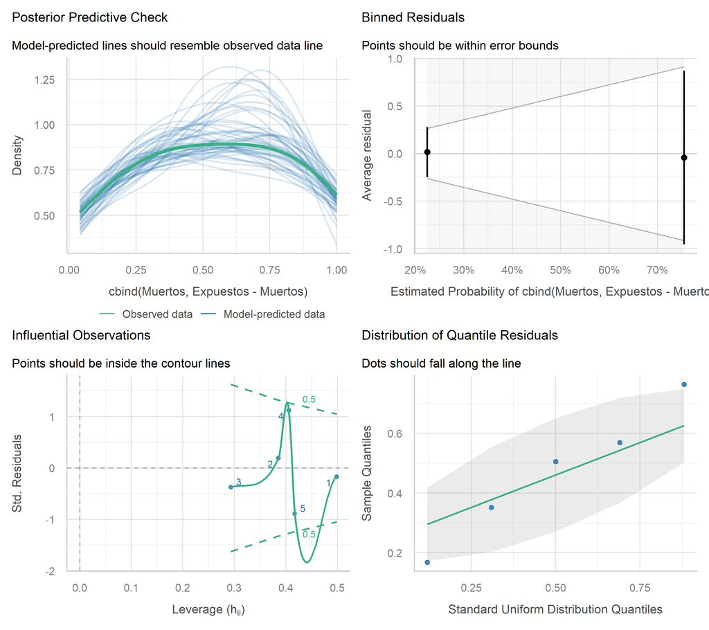

```r
check_model(modelo3.1)
```

Los residuos se distribuyen uniformemente y la capacidad predictiva es razonable.

**Envelope y Cook’s Distance**

**Ver código**

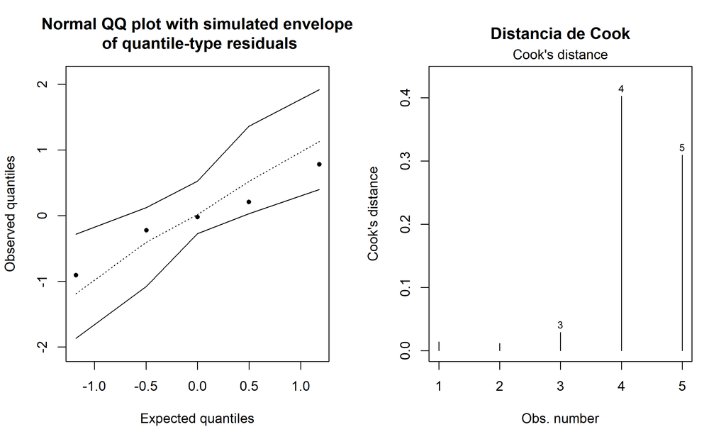

```r
old <- sink(tempfile())
par(mfrow = c(1, 2))
envelope(modelo3.1)
plot(modelo3.1, which = 4, main = "Distancia de Cook")
abline(h = 4 / 3, col = "red", lty = 2)
```

**Ver código**

```r
sink(old)
```

**Sobredispersión**

**Ver código**

```r
check_overdispersion(modelo3.1)
```

```
# Overdispersion test

 dispersion ratio = 0.997
          p-value = 0.944
```

**Tip**

## 3.6 f) Dosis Letal 50% (DL₅₀)

**Ver código**

```r
beta0 <- coef(modelo3.1)[1]
beta1 <- coef(modelo3.1)[2]
DL50  <- -(beta0 / beta1)
cat("DL50:", round(DL50, 6), "\n")
```

```
DL50: 0.684582
```

**Intervalo de confianza al 95% (Método Delta):**

**Ver código**

```r
vcov_mat <- vcov(modelo3.1)
var_dl50 <- (1/beta1^2) * (vcov_mat[1,1] -
               2*(beta0/beta1)*vcov_mat[1,2] +
               (beta0^2/beta1^2)*vcov_mat[2,2])
se_dl50 <- sqrt(var_dl50)
ic <- c(DL50 - 1.96*se_dl50, DL50 + 1.96*se_dl50)
cat("IC 95%: [", round(ic[1], 4), ",", round(ic[2], 4), "]\n")
```

```
IC 95%: [ 0.6401 , 0.7291 ]
```

**Resultado**

Con una dosis de **0.6846** se garantiza una mortalidad del 50%. El IC 95% es [0.6401, 0.7291].

# 4 Ejercicio 4 — Cáncer en ratones (Carcinógeno 2-AAF)

**Contexto**

**Fuente:** Zhang y Zelterman (1999)

Experimento donde ratones hembra fueron alimentados con dosis bajas del carcinógeno **2-acetilaminofluoreno (2-AAF)**. Se analiza la incidencia de cáncer de **hígado** y **vejiga** por separado.

**Ver código**

```r
datos_cancer |>
  mutate(Tasa_Higado = round(Tasa_Higado, 4),
         Tasa_Vejiga = round(Tasa_Vejiga, 4)) |>
  kable(caption = "Datos de incidencia de cáncer por dosis de carcinógeno") |>
  kable_styling(bootstrap_options = c("striped", "hover", "condensed"), full_width = FALSE)
```

Datos de incidencia de cáncer por dosis de carcinógeno

| Dosis | Exp_Higado | Enf_Higado | Exp_Vejiga | Enf_Vejiga | Tasa_Higado | Tasa_Vejiga |
| --- | --- | --- | --- | --- | --- | --- |
| 0.00 | 555 | 6 | 101 | 1 | 0.0108 | 0.0099 |
| 0.30 | 2014 | 34 | 443 | 5 | 0.0169 | 0.0113 |
| 0.35 | 1102 | 20 | 200 | 0 | 0.0181 | 0.0000 |
| 0.45 | 550 | 15 | 103 | 2 | 0.0273 | 0.0194 |
| 0.60 | 441 | 13 | 66 | 2 | 0.0295 | 0.0303 |
| 0.75 | 382 | 17 | 75 | 12 | 0.0445 | 0.1600 |
| 1.00 | 213 | 19 | 31 | 21 | 0.0892 | 0.6774 |
| 1.50 | 211 | 24 | 11 | 11 | 0.1137 | 1.0000 |

## 4.1 a) Ajuste y selección de modelos

**Ver código**

```r
mod_bin_higado  <- glm(cbind(Enf_Higado, Exp_Higado - Enf_Higado) ~ Dosis,
                       family = binomial(link = "logit"), data = datos_cancer)
mod_pois_higado <- glm(Enf_Higado ~ Dosis,
                       family = poisson(link = "log"), data = datos_cancer)
mod_bin_vejiga  <- glm(cbind(Enf_Vejiga, Exp_Vejiga - Enf_Vejiga) ~ Dosis,
                       family = binomial(link = "logit"), data = datos_cancer)
mod_pois_vejiga <- glm(Enf_Vejiga ~ Dosis,
                       family = poisson(link = "log"), data = datos_cancer)

data.frame(
  Órgano  = c("Hígado", "Hígado", "Vejiga", "Vejiga"),
  Modelo  = c("Binomial", "Poisson", "Binomial", "Poisson"),
  AIC     = round(c(AIC(mod_bin_higado), AIC(mod_pois_higado),
                    AIC(mod_bin_vejiga), AIC(mod_pois_vejiga)), 3)
) |>
  kable(caption = "Comparación de modelos por AIC") |>
  kable_styling(bootstrap_options = c("striped", "hover"), full_width = FALSE) |>
  row_spec(c(1, 3), bold = TRUE, color = "white", background = "#2c7bb6")
```

Comparación de modelos por AIC

| Órgano | Modelo | AIC |
| --- | --- | --- |
| Hígado | Binomial | 45.494 |
| Hígado | Poisson | 65.324 |
| Vejiga | Binomial | 34.019 |
| Vejiga | Poisson | 59.618 |

**Decisión**

## 4.2 b) Pruebas de hipótesis

**Hígado — Wald**

**Ver código**

```r
summary(mod_bin_higado)
```

```
Call:
glm(formula = cbind(Enf_Higado, Exp_Higado - Enf_Higado) ~ Dosis,
    family = binomial(link = "logit"), data = datos_cancer)

Coefficients:
            Estimate Std. Error z value Pr(>|z|)
(Intercept)  -4.5083     0.1478 -30.501   <2e-16 ***
Dosis         1.7624     0.1864   9.457   <2e-16 ***
---
Signif. codes:  0 '***' 0.001 '**' 0.01 '*' 0.05 '.' 0.1 ' ' 1

(Dispersion parameter for binomial family taken to be 1)

    Null deviance: 77.6029  on 7  degrees of freedom
Residual deviance:  4.5217  on 6  degrees of freedom
AIC: 45.494

Number of Fisher Scoring iterations: 4
```

P-valor = **2e-16 < 0.05** → La dosis afecta significativamente la incidencia de cáncer de hígado.

**Vejiga — Wald**

**Ver código**

```r
summary(mod_bin_vejiga)
```

```
Call:
glm(formula = cbind(Enf_Vejiga, Exp_Vejiga - Enf_Vejiga) ~ Dosis,
    family = binomial(link = "logit"), data = datos_cancer)

Coefficients:
            Estimate Std. Error z value Pr(>|z|)
(Intercept)  -7.4324     0.5831  -12.75   <2e-16 ***
Dosis         7.8752     0.7821   10.07   <2e-16 ***
---
Signif. codes:  0 '***' 0.001 '**' 0.01 '*' 0.05 '.' 0.1 ' ' 1

(Dispersion parameter for binomial family taken to be 1)

    Null deviance: 214.94  on 7  degrees of freedom
Residual deviance:  11.45  on 6  degrees of freedom
AIC: 34.019

Number of Fisher Scoring iterations: 5
```

P-valor = **2e-16 < 0.05** → La dosis afecta significativamente la incidencia de cáncer de vejiga.

**Razón de Verosimilitudes**

**Ver código**

```r
modelo4.01 <- glm(cbind(Enf_Higado, Exp_Higado - Enf_Higado) ~ 1,
                  family = binomial(link = "logit"), data = datos_cancer)
modelo4.02 <- glm(cbind(Enf_Vejiga, Exp_Vejiga - Enf_Vejiga) ~ 1,
                  family = binomial(link = "logit"), data = datos_cancer)

cat("--- Hígado ---\n")
```

```
--- Hígado ---
```

**Ver código**

```r
lrtest(modelo4.01, mod_bin_higado)
```

| #Df | LogLik | Df | Chisq | Pr(>Chisq) |
| --- | --- | --- | --- | --- |
| 1 | -57.28783 | NA | NA | NA |
| 2 | -20.74721 | 1 | 73.08125 | 0 |

**Ver código**

```r
cat("--- Vejiga ---\n")
```

```
--- Vejiga ---
```

**Ver código**

```r
lrtest(modelo4.02, mod_bin_vejiga)
```

| #Df | LogLik | Df | Chisq | Pr(>Chisq) |
| --- | --- | --- | --- | --- |
| 1 | -116.75706 | NA | NA | NA |
| 2 | -15.00956 | 1 | 203.495 | 0 |

En ambos casos p-valor = 2.2e-16 → La dosis es un predictor **esencial** en los dos modelos.

## 4.3 c) Diagnóstico

**Hígado — Diagnóstico general**

**Ver código**

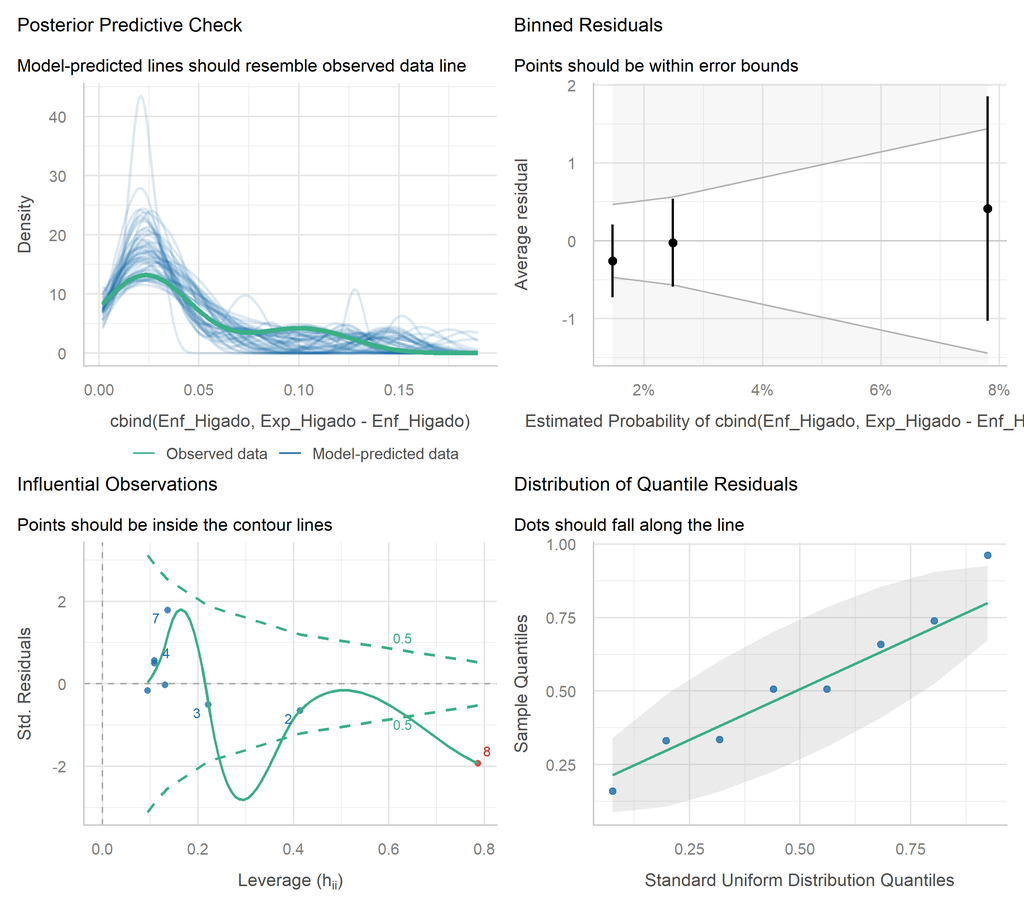

```r
check_model(mod_bin_higado)
```

El modelo se comporta bien: residuos uniformes y capacidad predictiva razonable.

**Hígado — Envelope**

**Ver código**

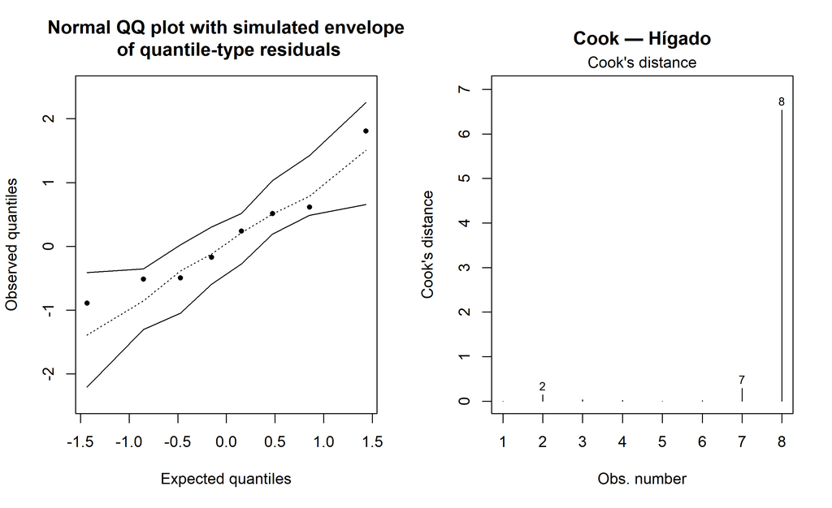

```r
old <- sink(tempfile())
par(mfrow = c(1, 2))
envelope(mod_bin_higado)
plot(mod_bin_higado, which = 4, main = "Cook — Hígado")
```

**Ver código**

```r
sink(old)
```

Se identifica un valor influyente en dosis = 1.50. El envelope no muestra problemas. **Sin sobredispersión.**

**Vejiga — Diagnóstico general**

**Ver código**

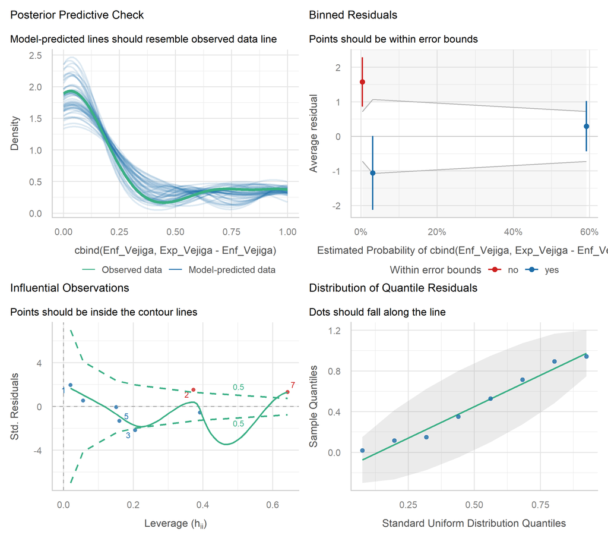

```r
check_model(mod_bin_vejiga)
```

**Vejiga — Envelope**

**Ver código**

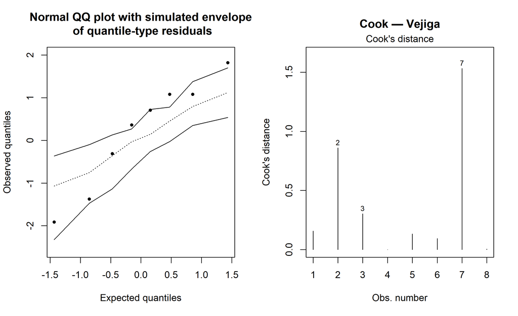

```r
old <- sink(tempfile())
par(mfrow = c(1, 2))
envelope(mod_bin_vejiga)
plot(mod_bin_vejiga, which = 4, main = "Cook — Vejiga")
```

**Ver código**

```r
sink(old)
```

## 4.4 d) Interpretación de parámetros

| Modelo | Exp(β̂) | Interpretación |
| --- | --- | --- |
| **Hígado** | exp(1.7624) = **5.826** | Por cada unidad adicional de dosis, el *odds* de cáncer de hígado se multiplica por **5.826**. |
| **Vejiga** | exp(7.8752) = **2,631.2** | Por cada unidad adicional de dosis, el *odds* de cáncer de vejiga se multiplica por **2,631.2**. |

# 5 Ejercicio 5 — Fallas en equipos electrónicos (Modelo Poisson)

**Contexto**

**Fuente:** Jorgenson (1961)

Datos de fallas en piezas electrónicas que operan en dos modos. Se registra el tiempo de funcionamiento en cada modo y el número total de fallas.

**Ver código**

```r
datos_fallas |>
  kable(caption = "Fallas en equipos electrónicos por tiempo de operación") |>
  kable_styling(bootstrap_options = c("striped", "hover"), full_width = FALSE)
```

Fallas en equipos electrónicos por tiempo de operación

| Modo1 | Modo2 | Fallas |
| --- | --- | --- |
| 33.3 | 25.3 | 15 |
| 52.2 | 14.4 | 9 |
| 64.7 | 32.5 | 14 |
| 137.0 | 20.5 | 24 |
| 125.9 | 97.6 | 27 |
| 116.3 | 53.6 | 27 |
| 131.7 | 56.6 | 23 |
| 85.0 | 87.3 | 18 |
| 91.9 | 47.8 | 22 |

## 5.1 a) Selección del mejor modelo Poisson

**Ver código**

```r
modelo5.1 <- glm(Fallas ~ Modo1 + Modo2, data = datos_fallas,
                 family = poisson(link = "log"))
modelo5.2 <- glm(Fallas ~ Modo1 + Modo2, data = datos_fallas,
                 family = poisson(link = "identity"))
modelo5.3 <- glm(Fallas ~ Modo1 + Modo2, data = datos_fallas,
                 family = poisson(link = "sqrt"))

data.frame(
  Enlace    = c("Log", "Identidad", "Raíz cuadrada"),
  AIC       = round(c(AIC(modelo5.1),      AIC(modelo5.2),      AIC(modelo5.3)),      4),
  Desviance = round(c(deviance(modelo5.1), deviance(modelo5.2), deviance(modelo5.3)), 4)
) |>
  kable(caption = "Comparación de funciones de enlace — Poisson") |>
  kable_styling(bootstrap_options = c("striped", "hover"), full_width = FALSE) |>
  row_spec(1, bold = TRUE, color = "white", background = "#2c7bb6")
```

Comparación de funciones de enlace — Poisson

| Enlace | AIC | Desviance |
| --- | --- | --- |
| Log | 53.0601 | 4.0033 |
| Identidad | 53.2539 | 4.1971 |
| Raíz cuadrada | 53.0909 | 4.0341 |

**Modelo seleccionado: Enlace Log**

Tanto el AIC como la devianza apuntan al **enlace logarítmico** como el mejor modelo.

## 5.2 b) ¿El número de fallas depende del Modo 1?

**Prueba de Wald**

**Ver código**

```r
summary(modelo5.1)
```

```
Call:
glm(formula = Fallas ~ Modo1 + Modo2, family = poisson(link = "log"),
    data = datos_fallas)

Coefficients:
            Estimate Std. Error z value Pr(>|z|)
(Intercept) 2.175168   0.255456   8.515  < 2e-16 ***
Modo1       0.007015   0.002429   2.888  0.00387 **
Modo2       0.002549   0.002835   0.899  0.36852
---
Signif. codes:  0 '***' 0.001 '**' 0.01 '*' 0.05 '.' 0.1 ' ' 1

(Dispersion parameter for poisson family taken to be 1)

    Null deviance: 16.9964  on 8  degrees of freedom
Residual deviance:  4.0033  on 6  degrees of freedom
AIC: 53.06

Number of Fisher Scoring iterations: 4
```

Modo 1 es significativo (p-valor = **0.00387 < 0.05**) → el tiempo en Modo 1 **sí afecta** el número de fallas.

**Razón de Verosimilitudes — Modo 1**

**Ver código**

```r
modelo5.01 <- glm(Fallas ~ Modo2, data = datos_fallas, family = poisson(link = "log"))
lrtest(modelo5.01, modelo5.1)
```

| #Df | LogLik | Df | Chisq | Pr(>Chisq) |
| --- | --- | --- | --- | --- |
| 2 | -27.70645 | NA | NA | NA |
| 3 | -23.53003 | 1 | 8.352835 | 0.0038509 |

P-valor = **0.003851 < 0.05** → el modelo completo es superior al reducido. El Modo 1 es un factor relevante.

## 5.3 c) ¿El número de fallas depende del Modo 2?

**Razón de Verosimilitudes — Modo 2**

**Ver código**

```r
modelo5.02 <- glm(Fallas ~ Modo1, data = datos_fallas, family = poisson(link = "log"))
lrtest(modelo5.02, modelo5.1)
```

| #Df | LogLik | Df | Chisq | Pr(>Chisq) |
| --- | --- | --- | --- | --- |
| 2 | -23.93228 | NA | NA | NA |
| 3 | -23.53003 | 1 | 0.8045079 | 0.369749 |

P-valor = **0.3697 > 0.05** → **No hay diferencias** entre el modelo completo y el reducido. El Modo 2 **no es** un factor importante.

## 5.4 d) Diagnóstico del modelo

**Diagnóstico general**

**Ver código**

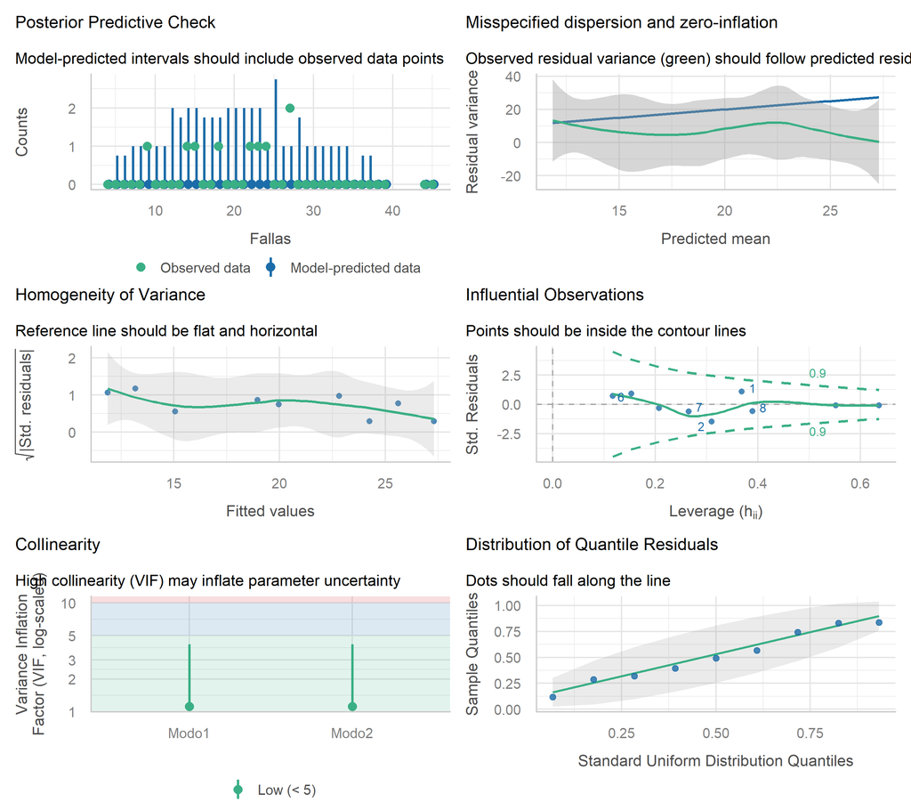

```r
check_model(modelo5.1)
```

Sin problemas de multicolinealidad. Residuos uniformes. Buen modelamiento predictivo. Sin heterodasticidad.

**Envelope y Cook’s Distance**

**Ver código**

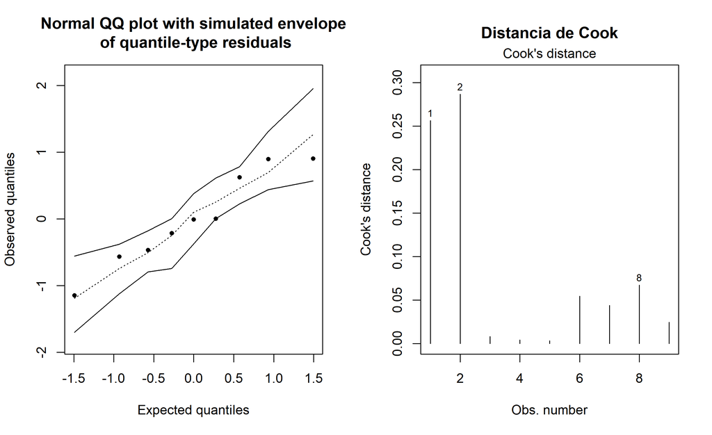

```r
old <- sink(tempfile())
par(mfrow = c(1, 2))
envelope(modelo5.1)
plot(modelo5.1, which = 4, main = "Distancia de Cook")
```

**Ver código**

```r
sink(old)
```

**Sobredispersión**

**Ver código**

```r
check_overdispersion(modelo5.1)
```

```
# Overdispersion test

       dispersion ratio = 0.658
  Pearson's Chi-Squared = 3.951
                p-value = 0.683
```

**Tip**

El envelope se ve muy bien. Sin valores influyentes. **Sin sobredispersión.** El modelo cumple con todos los supuestos.

## 5.5 e) Interpretación de parámetros

> **exp(0.007015) = 1.0070** → Por cada unidad adicional de tiempo en el **Modo 1** (manteniendo constante el Modo 2), el número esperado de fallas aumenta un **0.70%**.

# 6 Ejercicio 6 — Lesiones por virus y rayos X (Modelo Poisson)

**Contexto**

**Fuente:** Olsson (2002, p. 29)

Se contó el número de lesiones causadas por un virus tras distintos tiempos de exposición a rayos X.

**Ver código**

```r
datos_lesiones <- data.frame(
  tiempo   = c(0, 15, 30, 45, 60),
  lesiones = c(271, 108, 59, 29, 12)
)
datos_lesiones |>
  kable(caption = "Lesiones virales por tiempo de exposición a rayos X") |>
  kable_styling(bootstrap_options = c("striped", "hover"), full_width = FALSE)
```

Lesiones virales por tiempo de exposición a rayos X

| tiempo | lesiones |
| --- | --- |
| 0 | 271 |
| 15 | 108 |
| 30 | 59 |
| 45 | 29 |
| 60 | 12 |

## 6.1 a) Gráfico: lesiones vs tiempo de exposición

**Ver código**

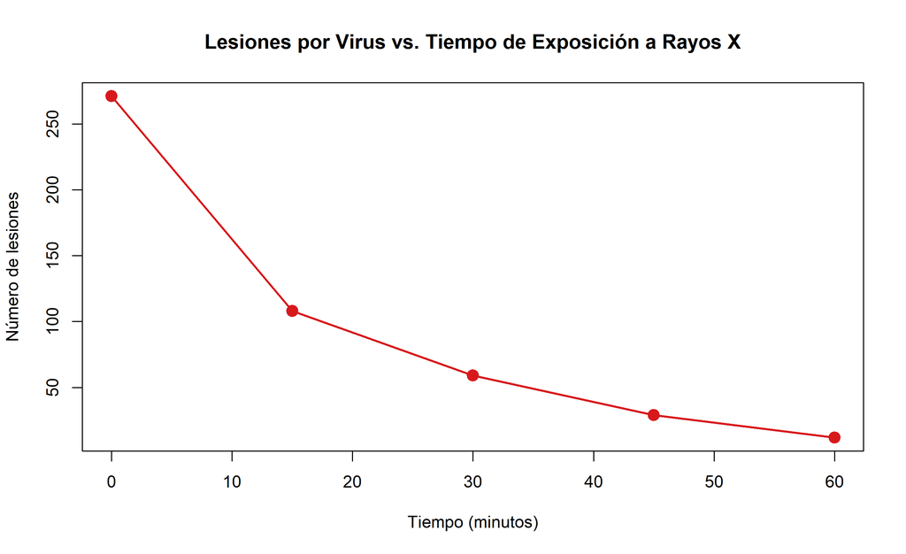

```r
plot(x = datos_lesiones$tiempo, y = datos_lesiones$lesiones,
     main = "Lesiones por Virus vs. Tiempo de Exposición a Rayos X",
     xlab = "Tiempo (minutos)", ylab = "Número de lesiones",
     pch = 19, col = "#d7191c", cex = 1.5)
lines(datos_lesiones$tiempo, datos_lesiones$lesiones, col = "#d7191c", lwd = 2)
```

Se observa una **relación inversa**: a mayor tiempo de exposición, menor número de lesiones.

## 6.2 b) Selección de modelo Poisson

**Ver código**

```r
modelo6.1 <- glm(lesiones ~ tiempo, family = poisson(link = "log"),      data = datos_lesiones)
modelo6.2 <- glm(lesiones ~ tiempo, family = poisson(link = "identity"), data = datos_lesiones)
modelo6.3 <- glm(lesiones ~ tiempo, family = poisson(link = "sqrt"),     data = datos_lesiones)

data.frame(
  Enlace    = c("Log", "Identidad", "Raíz cuadrada"),
  AIC       = round(c(AIC(modelo6.1),      AIC(modelo6.2),      AIC(modelo6.3)),      4),
  Desviance = round(c(deviance(modelo6.1), deviance(modelo6.2), deviance(modelo6.3)), 4)
) |>
  kable(caption = "Comparación de funciones de enlace — Lesiones virales") |>
  kable_styling(bootstrap_options = c("striped", "hover"), full_width = FALSE) |>
  row_spec(1, bold = TRUE, color = "white", background = "#2c7bb6")
```

Comparación de funciones de enlace — Lesiones virales

| Enlace | AIC | Desviance |
| --- | --- | --- |
| Log | 35.7186 | 2.2906 |
| Identidad | 107.6124 | 74.1844 |
| Raíz cuadrada | 59.3748 | 25.9468 |

**Modelo seleccionado: Enlace Log**

Es muy superior a los demás, con el menor AIC y desvío.

## 6.3 c) Pruebas de hipótesis

**Prueba de Wald**

**Ver código**

```r
summary(modelo6.1)
```

```
Call:
glm(formula = lesiones ~ tiempo, family = poisson(link = "log"),
    data = datos_lesiones)

Coefficients:
             Estimate Std. Error z value Pr(>|z|)
(Intercept)  5.571340   0.056714   98.24   <2e-16 ***
tiempo      -0.051326   0.002972  -17.27   <2e-16 ***
---
Signif. codes:  0 '***' 0.001 '**' 0.01 '*' 0.05 '.' 0.1 ' ' 1

(Dispersion parameter for poisson family taken to be 1)

    Null deviance: 413.1314  on 4  degrees of freedom
Residual deviance:   2.2906  on 3  degrees of freedom
AIC: 35.719

Number of Fisher Scoring iterations: 3
```

P-valor = **2e-16 < 0.05** → El tiempo de exposición es estadísticamente significativo.

**Razón de Verosimilitudes**

**Ver código**

```r
modelo6.0 <- glm(lesiones ~ 1, family = poisson(link = "log"), data = datos_lesiones)
lrtest(modelo6.0, modelo6.1)
```

| #Df | LogLik | Df | Chisq | Pr(>Chisq) |
| --- | --- | --- | --- | --- |
| 1 | -221.27971 | NA | NA | NA |
| 2 | -15.85929 | 1 | 410.8408 | 0 |

El modelo completo (con tiempo) es **muy superior** al modelo nulo. El tiempo es una variable crucial.

## 6.4 d) Diagnóstico

**Diagnóstico general**

**Ver código**

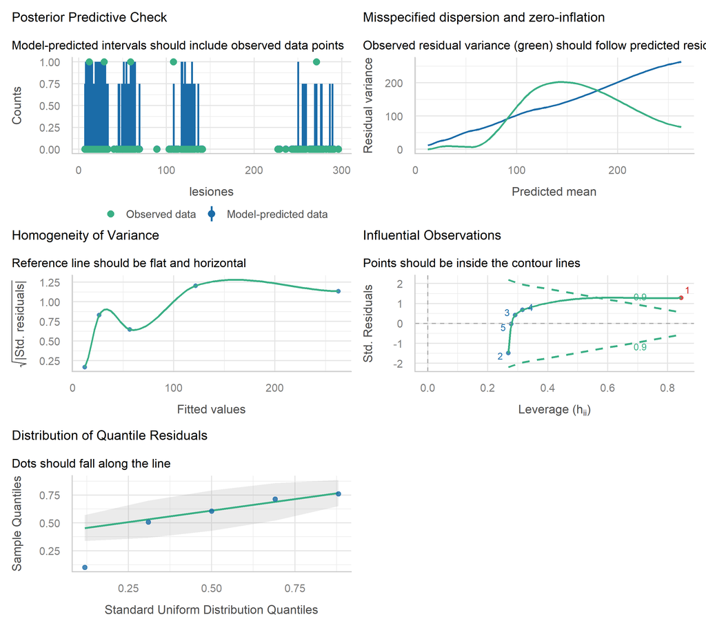

```r
check_model(modelo6.1)
```

Se observan problemas en las predicciones, posible heterodasticidad, residuos no uniformes y un posible valor influyente.

**Envelope y Cook’s Distance**

**Ver código**

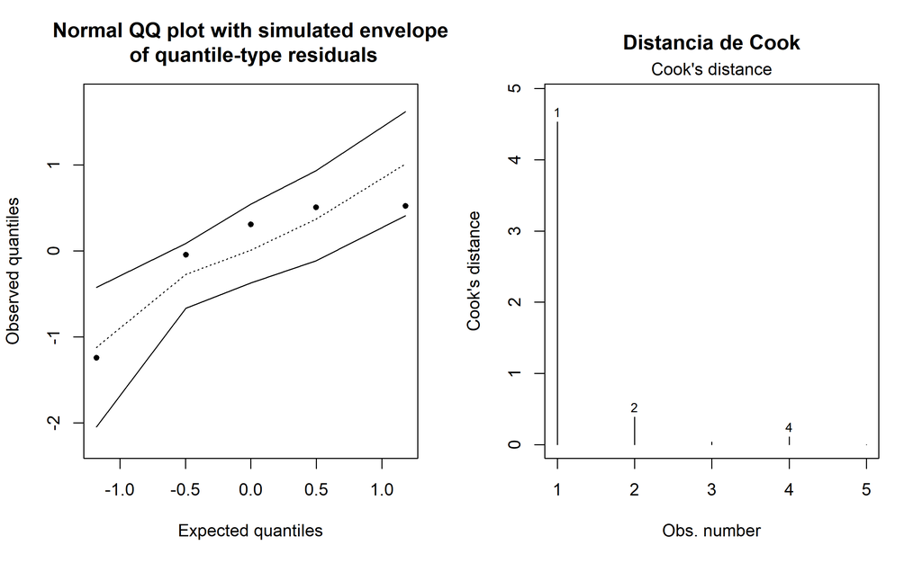

```r
old <- sink(tempfile())
par(mfrow = c(1, 2))
envelope(modelo6.1)
plot(modelo6.1, which = 4, main = "Distancia de Cook")
```

**Ver código**

```r
sink(old)
```

**Sobredispersión**

**Ver código**

```r
check_overdispersion(modelo6.1)
```

```
# Overdispersion test

       dispersion ratio = 0.748
  Pearson's Chi-Squared = 2.245
                p-value = 0.523
```

**Warning**

El envelope no presenta inconvenientes. El dato influyente es claro en la gráfica de Cook. **No se detecta sobredispersión** → los problemas se deben principalmente al dato influyente.